# shopify_DS_F22

Cheryl Bui

5/17/2022

```r
library(tidyverse)
```

## Question 1

### Loading data, EDA

```r
data = read.csv('./2019 Winter Data Science Intern Challenge Data Set.csv')

head(data)
```

```
##   order_id shop_id user_id order_amount total_items payment_method
## 1        1      53     746          224           2           cash
## 2        2      92     925           90           1           cash
## 3        3      44     861          144           1           cash
## 4        4      18     935          156           1    credit_card
## 5        5      18     883          156           1    credit_card
## 6        6      58     882          138           1    credit_card
##            created_at
## 1 2017-03-13 12:36:56
## 2 2017-03-03 17:38:52
## 3  2017-03-14 4:23:56
## 4 2017-03-26 12:43:37
## 5  2017-03-01 4:35:11
## 6 2017-03-14 15:25:01
```

```r
summary(data)
```

```
##     order_id       shop_id          user_id       order_amount
##  Min.   :   1   Min.   :  1.00   Min.   :607.0   Min.   :    90
##  1st Qu.:1251   1st Qu.: 24.00   1st Qu.:775.0   1st Qu.:   163
##  Median :2500   Median : 50.00   Median :849.0   Median :   284
##  Mean   :2500   Mean   : 50.08   Mean   :849.1   Mean   :  3145
##  3rd Qu.:3750   3rd Qu.: 75.00   3rd Qu.:925.0   3rd Qu.:   390
##  Max.   :5000   Max.   :100.00   Max.   :999.0   Max.   :704000
##   total_items       payment_method      created_at
##  Min.   :   1.000   Length:5000        Length:5000
##  1st Qu.:   1.000   Class :character   Class :character
##  Median :   2.000   Mode  :character   Mode  :character
##  Mean   :   8.787
##  3rd Qu.:   3.000
##  Max.   :2000.000
```

```r
psych::describe(data)
```

```
##                 vars    n    mean       sd median trimmed     mad min    max
## order_id           1 5000 2500.50  1443.52 2500.5 2500.50 1853.25   1   5000
## shop_id            2 5000   50.08    29.01   50.0   49.99   37.06   1    100
## user_id            3 5000  849.09    87.80  849.0  849.36  111.19 607    999
## order_amount       4 5000 3145.13 41282.54  284.0  287.39  174.95  90 704000
## total_items        5 5000    8.79   116.32    2.0    1.88    1.48   1   2000
## payment_method*    6 5000    2.02     0.81    2.0    2.02    1.48   1      3
## created_at*        7 5000 2496.30  1441.46 2495.5 2496.29 1851.77   1   4991
##                  range  skew kurtosis     se
## order_id          4999  0.00    -1.20  20.41
## shop_id             99  0.01    -1.22   0.41
## user_id            392 -0.03    -1.09   1.24
## order_amount    703910 16.67   279.51 583.82
## total_items       1999 17.06   288.96   1.65
## payment_method*      2 -0.03    -1.47   0.01
## created_at*       4990  0.00    -1.20  20.39
```

```r
cat('duplicated:', any(duplicated(data)))
```

```
## duplicated: FALSE
```

```r
# add another column for average price of a pair of sneaker
data$price_per_sneakers = data$order_amount / data$total_items
```

From the summary statistics, it looks like the distribution of order value and average price is right-skewed. We’ll take a look at their histogram plot. Since the data is skewed, I’ll draw in log scale

As all values of order are greater than 0, we dont have to +1

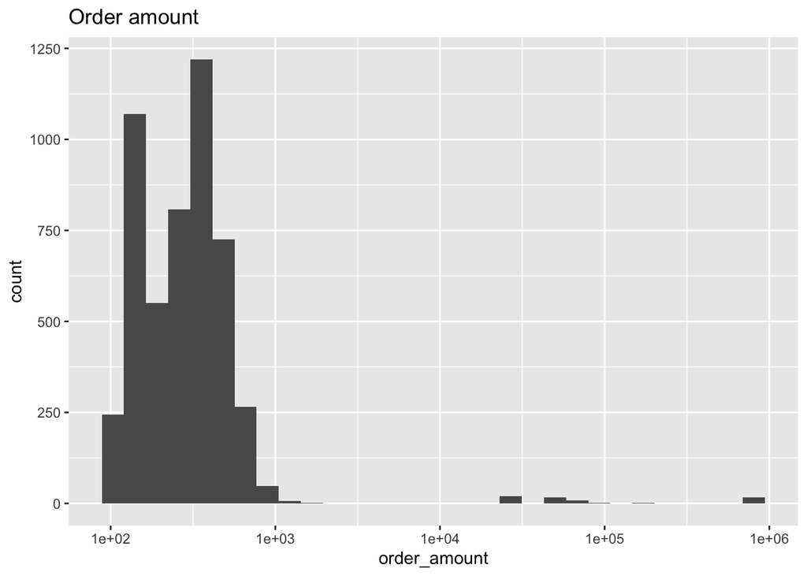

```r
# order amount
ggplot(data, aes(x = order_amount)) +
  geom_histogram() +
  # geom_histogram(bins=10) +
  scale_x_log10() +
  ggtitle("Order amount")
```

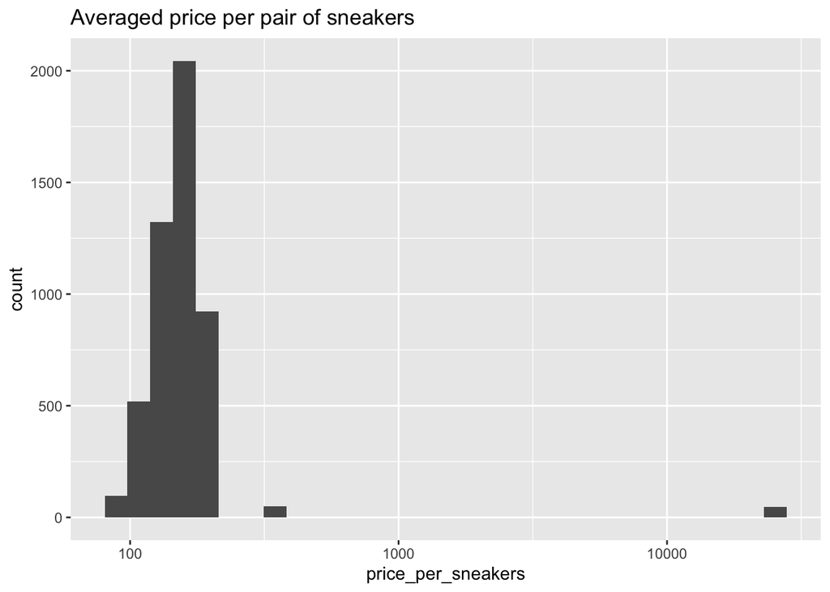

```r
# shoe price
ggplot(data, aes(x = price_per_sneakers)) +
  geom_histogram() +
  # geom_histogram(bins=10) +
  scale_x_log10() +
  ggtitle("Averaged price per pair of sneakers")
```

Again, we can see that very few orders surpass 10,000 USD. There are a few pairs of sneaker at the price of over 20,000USD. These are flags for outliers or fraud transactions. There are also a cluster of sneaker pairs at about 10^2.5 = roughly 350 USD, which is quite pricey but still acceptable, so I will not consider them as outliers. Let’s inspect these suspicious transactions

```r
data %>% filter(price_per_sneakers > 10^3)
```

```
##    order_id shop_id user_id order_amount total_items payment_method
## 1       161      78     990        25725           1    credit_card
## 2       491      78     936        51450           2          debit
## 3       494      78     983        51450           2           cash
## 4       512      78     967        51450           2           cash
## 5       618      78     760        51450           2           cash
## 6       692      78     878       154350           6          debit
## 7      1057      78     800        25725           1          debit
## 8      1194      78     944        25725           1          debit
## 9      1205      78     970        25725           1    credit_card
## 10     1260      78     775        77175           3    credit_card
## 11     1385      78     867        25725           1           cash
## 12     1420      78     912        25725           1           cash
## 13     1453      78     812        25725           1    credit_card
## 14     1530      78     810        51450           2           cash
```

[output cut: 79 more lines]

```r
data %>% filter(order_amount >= 10^4 )
```

```
##    order_id shop_id user_id order_amount total_items payment_method
## 1        16      42     607       704000        2000    credit_card
## 2        61      42     607       704000        2000    credit_card
## 3       161      78     990        25725           1    credit_card
## 4       491      78     936        51450           2          debit
## 5       494      78     983        51450           2           cash
## 6       512      78     967        51450           2           cash
## 7       521      42     607       704000        2000    credit_card
## 8       618      78     760        51450           2           cash
## 9       692      78     878       154350           6          debit
## 10     1057      78     800        25725           1          debit
## 11     1105      42     607       704000        2000    credit_card
## 12     1194      78     944        25725           1          debit
## 13     1205      78     970        25725           1    credit_card
## 14     1260      78     775        77175           3    credit_card
```

[output cut: 113 more lines]

All of the 25,000USD-sneakers are from shop 78. All of the large amount transactions are from shop 78 and 42. Let’s see the other transactions by this shop, as well as the users buying from this shop.

```r
data[data$shop_id == 78,]
```

```
##      order_id shop_id user_id order_amount total_items payment_method
## 161       161      78     990        25725           1    credit_card
## 491       491      78     936        51450           2          debit
## 494       494      78     983        51450           2           cash
## 512       512      78     967        51450           2           cash
## 618       618      78     760        51450           2           cash
## 692       692      78     878       154350           6          debit
## 1057     1057      78     800        25725           1          debit
## 1194     1194      78     944        25725           1          debit
## 1205     1205      78     970        25725           1    credit_card
## 1260     1260      78     775        77175           3    credit_card
## 1385     1385      78     867        25725           1           cash
## 1420     1420      78     912        25725           1           cash
## 1453     1453      78     812        25725           1    credit_card
## 1530     1530      78     810        51450           2           cash
```

[output cut: 79 more lines]

```r
unique(data[data$shop_id == 78, c('price_per_sneakers')])
```

```
## [1] 25725
```

```r
unique(data[data$shop_id == 78, c('user_id')])
```

```
##  [1] 990 936 983 967 760 878 800 944 970 775 867 912 812 810 855 709 834 707 935
## [20] 861 915 962 890 869 814 817 740 910 745 927 928 982 828 766 889 852 946 787
## [39] 960 756 969 866 997 818 823
```

```r
data[data$shop_id == 42,]
```

```
##      order_id shop_id user_id order_amount total_items payment_method
## 16         16      42     607       704000        2000    credit_card
## 41         41      42     793          352           1    credit_card
## 61         61      42     607       704000        2000    credit_card
## 309       309      42     770          352           1    credit_card
## 410       410      42     904          704           2    credit_card
## 521       521      42     607       704000        2000    credit_card
## 835       835      42     792          352           1           cash
## 836       836      42     819          704           2           cash
## 939       939      42     808         1056           3    credit_card
## 980       980      42     744          352           1          debit
## 1105     1105      42     607       704000        2000    credit_card
## 1363     1363      42     607       704000        2000    credit_card
## 1365     1365      42     797         1760           5           cash
## 1368     1368      42     926         1408           4           cash
```

[output cut: 89 more lines]

```r
unique(data[data$shop_id == 42, c('price_per_sneakers')])
```

```
## [1] 352
```

```r
unique(data[data$shop_id == 42, c('user_id')])
```

```
##  [1] 607 793 770 904 792 819 808 744 797 926 907 946 756 739 934 951 747 868 970
## [20] 726 830 839 975 886 962 859 788 736 809 872 720
```

All of the transactions from shop 78 and 42 look suspicious (every pair of sneaker is $25725 USD for shop 78 and 352 for shop 42). These are the two single value clusters we saw from the historgram. Let’s remove these 2 shops from our dataset, and report the statistics of this shop on the side. Let’s see the buyers from these two shops too

```r
buyers_42 = unique(data[data$shop_id == 42, c('user_id')])
buyers_78 = unique(data[data$shop_id == 78, c('user_id')])
common_fraud_buyers = intersect(buyers_78, buyers_42)
union_fraud_buyers = union(buyers_78, buyers_42)

cat('all fraud buyers: ',union_fraud_buyers)
```

```
## all fraud buyers:  990 936 983 967 760 878 800 944 970 775 867 912 812 810 855 709 834 707 935 861 915 962 890 869 814 817 740 910 745 927 928 982 828 766 889 852 946 787 960 756 969 866 997 818 823 607 793 770 904 792 819 808 744 797 926 907 739 934 951 747 868 726 830 839 975 886 859 788 736 80…
```

```r
cat('common fraud buyers: ',common_fraud_buyers)
```

```
## common fraud buyers:  970 962 946 756
```

```r
# let's see the other transactions that they make
data_by_user = data[data$user_id %in% union_fraud_buyers, ]
data_by_user <- data_by_user %>% group_by(user_id)

data_by_user
```

```
## # A tibble: 1,216 × 8
## # Groups:   user_id [72]
##    order_id shop_id user_id order_amount total_items payment_method created_at
##       <int>   <int>   <int>        <int>       <int> <chr>          <chr>
##  1        3      44     861          144           1 cash           2017-03-14 …
##  2        4      18     935          156           1 credit_card    2017-03-26 …
##  3        7      87     915          149           1 cash           2017-03-01 …
##  4       10      52     788          146           1 credit_card    2017-03-30 …
##  5       12      40     983          322           2 debit          2017-03-12 …
##  6       14     100     709          111           1 cash           2017-03-22 …
##  7       16      42     607       704000        2000 credit_card    2017-03-07 …
##  8       29      40     944          322           2 cash           2017-03-05 …
##  9       32      57     839          294           2 debit          2017-03-19 …
## 10       34       7     800          224           2 credit_card    2017-03-03 …
## # … with 1,206 more rows, and 1 more variable: price_per_sneakers <dbl>
```

```r
data_by_user %>% summarise( order_amount = mean(order_amount),
                            price_per_sneakers = mean(price_per_sneakers) ,
                            total_items = mean(total_items) ) %>%
                arrange(desc(order_amount))
```

```
## # A tibble: 72 × 4
##    user_id order_amount price_per_sneakers total_items
##      <int>        <dbl>              <dbl>       <dbl>
##  1     607      704000                352      2000
##  2     878       14267.              2469.        2.18
##  3     766        8008.              2705.        2.3
##  4     834        6019               1581.        2.11
##  5     915        5785.              1974.        2.07
##  6     962        5743.              1988.        1.71
##  7     775        5070.              1752.        1.75
##  8     817        5062.              1740.        1.88
##  9     928        5042.              1739.        1.75
## 10     855        4760.              3162.        1.59
## # … with 62 more rows
```

User 607 solely buy the large amount order. However, since the other user_ids starts from 700, I guess this is a system glitch or test. Half of other transactions are above $1000 / pair of sneaker, which is quite pricey but I’ll let it pass

Let’s see how the transactions look like without shop 78 and 42. Also, let’s check how frequent do the shops and buyers make their transaction

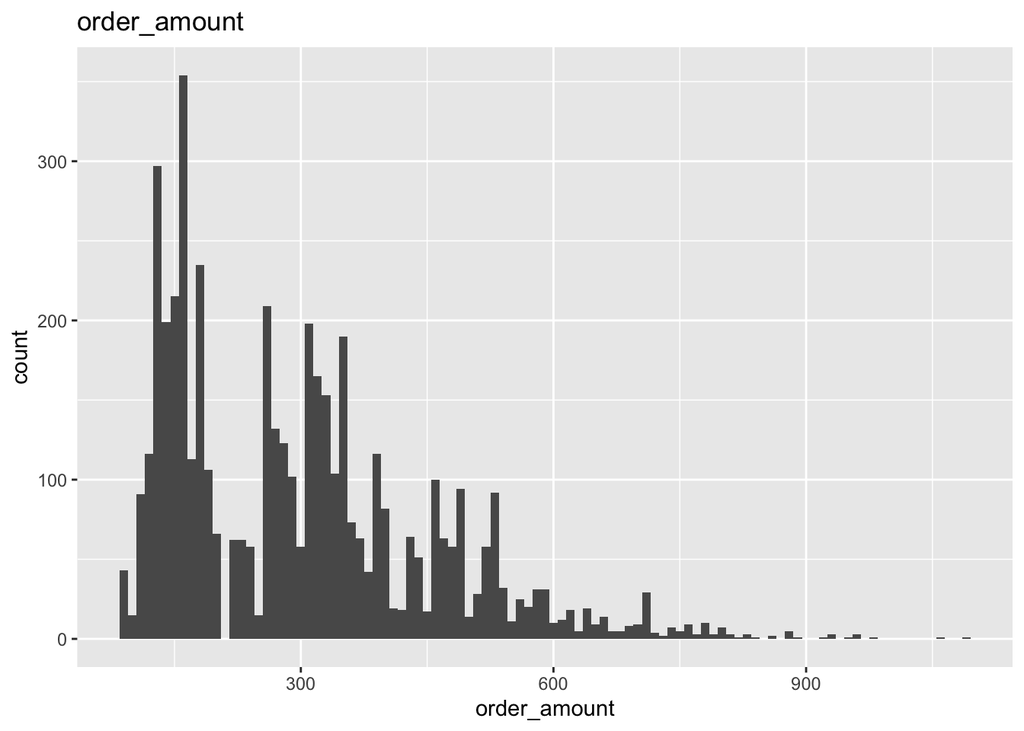

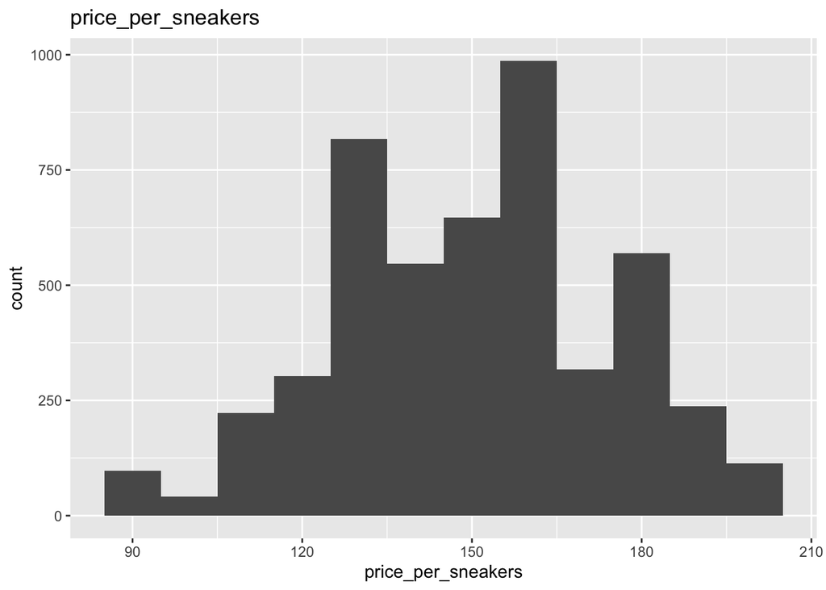

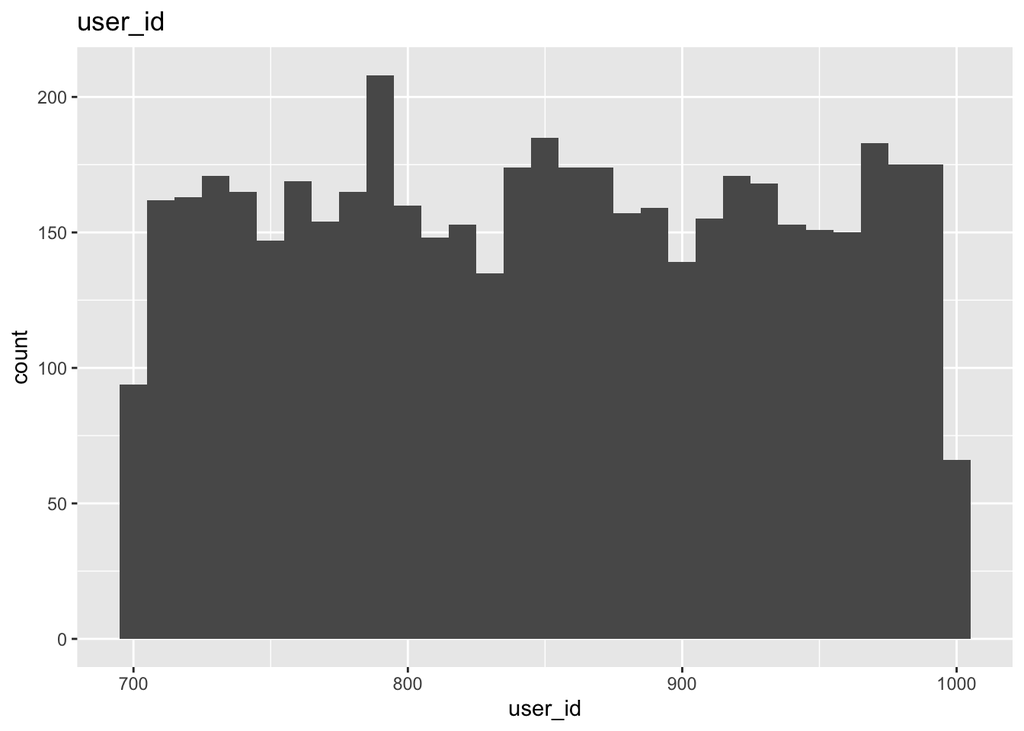

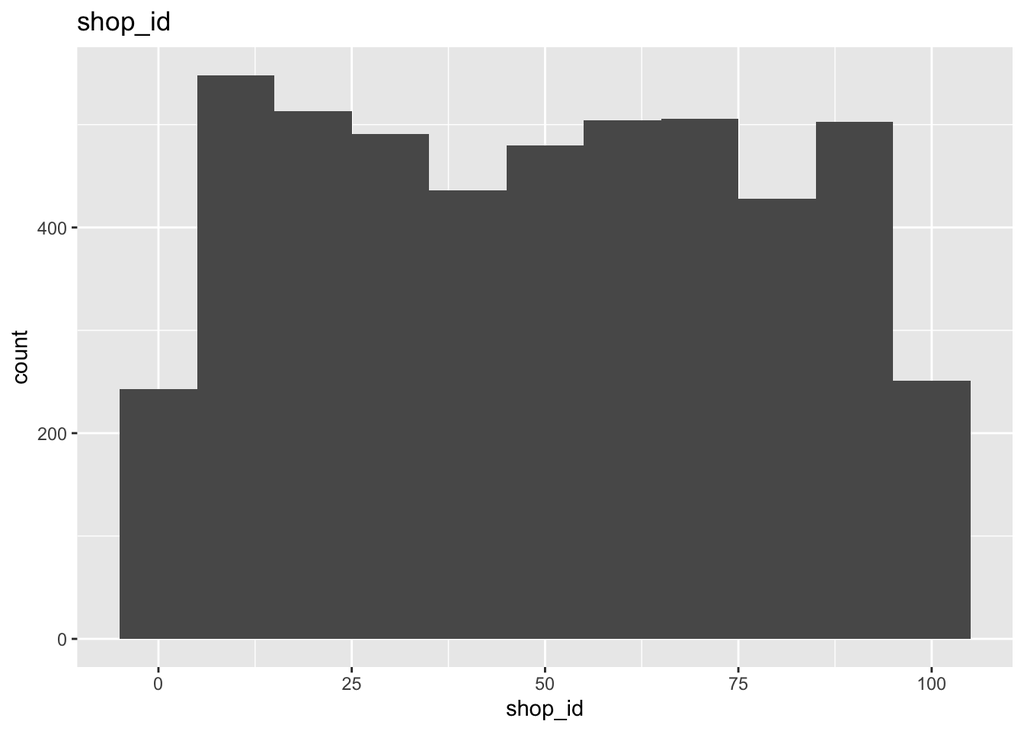

```r
data_clean = data[! data$shop_id %in% c(42, 78), ]

values_to_inspect = c('order_amount', 'price_per_sneakers', 'user_id', 'shop_id')

for(value in values_to_inspect){
  # order amount
  print(ggplot(data_clean, aes_string(x = value)) +
          geom_histogram(binwidth =10) +
          ggtitle(value)
        )
}
```

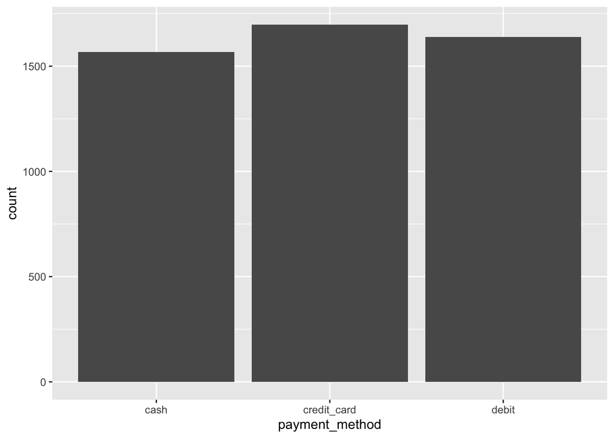

```r
ggplot(data_clean, aes(x = payment_method)) +
          geom_bar(stat = 'count')
```

```r
data_clean %>%
  group_by(user_id) %>%
  summarise(Freq = sum(total_items)) %>%
  arrange(desc(Freq))
```

```
## # A tibble: 300 × 2
##    user_id  Freq
##      <int> <int>
##  1     718    58
##  2     745    55
##  3     787    54
##  4     847    54
##  5     932    53
##  6     734    52
##  7     842    52
##  8     785    51
##  9     786    51
## 10     789    51
## # … with 290 more rows
```

```r
summary(data_clean)
```

```
##     order_id       shop_id         user_id       order_amount
##  Min.   :   1   Min.   :  1.0   Min.   :700.0   Min.   :  90.0
##  1st Qu.:1246   1st Qu.: 24.0   1st Qu.:776.0   1st Qu.: 163.0
##  Median :2499   Median : 50.0   Median :850.0   Median : 284.0
##  Mean   :2500   Mean   : 49.9   Mean   :849.9   Mean   : 300.2
##  3rd Qu.:3750   3rd Qu.: 74.0   3rd Qu.:925.0   3rd Qu.: 386.5
##  Max.   :5000   Max.   :100.0   Max.   :999.0   Max.   :1086.0
##   total_items    payment_method      created_at        price_per_sneakers
##  Min.   :1.000   Length:4903        Length:4903        Min.   : 90.0
##  1st Qu.:1.000   Class :character   Class :character   1st Qu.:132.0
##  Median :2.000   Mode  :character   Mode  :character   Median :153.0
##  Mean   :1.996                                         Mean   :150.4
##  3rd Qu.:3.000                                         3rd Qu.:166.0
##  Max.   :8.000                                         Max.   :201.0
```

```r
psych::describe(data_clean)
```

```
##                    vars    n    mean      sd median trimmed     mad min  max
## order_id              1 4903 2499.58 1444.22   2499 2499.42 1856.22   1 5000
## shop_id               2 4903   49.90   29.15     50   49.77   37.06   1  100
## user_id               3 4903  849.86   86.89    850  849.80  111.19 700  999
## order_amount          4 4903  300.16  155.94    284  282.37  170.50  90 1086
## total_items           5 4903    2.00    0.98      2    1.87    1.48   1    8
## payment_method*       6 4903    2.01    0.81      2    2.02    1.48   1    3
## created_at*           7 4903 2450.45 1414.82   2450 2450.36 1816.18   1 4900
## price_per_sneakers    8 4903  150.40   23.85    153  150.70   28.17  90  201
##                    range  skew kurtosis    se
## order_id            4999  0.00    -1.20 20.63
## shop_id               99  0.02    -1.23  0.42
## user_id              299  0.01    -1.20  1.24
## order_amount         996  1.00     0.94  2.23
## total_items            7  0.92     0.71  0.01
## payment_method*        2 -0.03    -1.47  0.01
## created_at*         4899  0.00    -1.20 20.21
## price_per_sneakers   111 -0.14    -0.48  0.34
```

```r
psych::describe(data[data$shop_id %in% c(42), ])
```

```
##                    vars  n      mean        sd median   trimmed     mad min
## order_id              1 51   2441.92   1484.46   2154   2433.85 1747.99  16
## shop_id               2 51     42.00      0.00     42     42.00    0.00  42
## user_id               3 51    758.59    125.99    770    752.41  198.67 607
## order_amount          4 51 235101.49 334860.64    704 206546.73  521.88 352
## total_items           5 51    667.90    951.31      2    586.78    1.48   1
## payment_method*       6 51      2.12      0.68      2      2.15    0.00   1
## created_at*           7 51     24.08     14.12     24     24.07   19.27   1
## price_per_sneakers    8 51    352.00      0.00    352    352.00    0.00 352
##                       max  range  skew kurtosis       se
## order_id             4883   4867  0.15    -1.25   207.87
## shop_id                42      0   NaN      NaN     0.00
## user_id               975    368  0.08    -1.36    17.64
## order_amount       704000 703648  0.69    -1.56 46889.87
## total_items          2000   1999  0.69    -1.56   133.21
## payment_method*         3      2 -0.14    -0.91     0.10
## created_at*            46     45  0.01    -1.36     1.98
## price_per_sneakers    352      0   NaN      NaN     0.00
```

```r
psych::describe(data[data$shop_id %in% c(78), ])
```

```
##                    vars  n     mean       sd  median  trimmed      mad   min
## order_id              1 46  2663.02  1338.52  2796.5  2687.24  1861.40   161
## shop_id               2 46    78.00     0.00    78.0    78.00     0.00    78
## user_id               3 46   867.74    81.31   866.5   870.08    94.89   707
## order_amount          4 46 49213.04 26472.23 51450.0 46034.21 38139.88 25725
## total_items           5 46     1.91     1.03     2.0     1.79     1.48     1
## payment_method*       6 46     2.00     0.89     2.0     2.00     1.48     1
## created_at*           7 46    23.50    13.42    23.5    23.50    17.05     1
## price_per_sneakers    8 46 25725.00     0.00 25725.0 25725.00     0.00 25725
##                       max  range  skew kurtosis      se
## order_id             4919   4758 -0.18    -1.11  197.35
## shop_id                78      0   NaN      NaN    0.00
## user_id               997    290 -0.18    -1.09   11.99
## order_amount       154350 128625  1.49     3.28 3903.12
## total_items             6      5  1.49     3.28    0.15
## payment_method*         3      2  0.00    -1.78    0.13
## created_at*            46     45  0.00    -1.28    1.98
## price_per_sneakers  25725      0   NaN      NaN    0.00
```

### Answer to question 1b: What metric would you report for this dataset?

- We probably should take a look at the 5-number summary statistics (1st, 2nd, 3rd quartile, min, max, and mean) and the other descriptive statistics (standard deviation) as a whole to generate a description of the data set for the numeric columns
- If we have to choose only 1 metric to replace mean, then the simplest answer is median. However exploratory data analysis should be carried out to detect suspicious transaction

### Answer to question 1c: What would be that value

- Median transaction amount is 284 for the uncleaned data
- For the cleaned data

```r
summary(data_clean)
```

```
##     order_id       shop_id         user_id       order_amount
##  Min.   :   1   Min.   :  1.0   Min.   :700.0   Min.   :  90.0
##  1st Qu.:1246   1st Qu.: 24.0   1st Qu.:776.0   1st Qu.: 163.0
##  Median :2499   Median : 50.0   Median :850.0   Median : 284.0
##  Mean   :2500   Mean   : 49.9   Mean   :849.9   Mean   : 300.2
##  3rd Qu.:3750   3rd Qu.: 74.0   3rd Qu.:925.0   3rd Qu.: 386.5
##  Max.   :5000   Max.   :100.0   Max.   :999.0   Max.   :1086.0
##   total_items    payment_method      created_at        price_per_sneakers
##  Min.   :1.000   Length:4903        Length:4903        Min.   : 90.0
##  1st Qu.:1.000   Class :character   Class :character   1st Qu.:132.0
##  Median :2.000   Mode  :character   Mode  :character   Median :153.0
##  Mean   :1.996                                         Mean   :150.4
##  3rd Qu.:3.000                                         3rd Qu.:166.0
##  Max.   :8.000                                         Max.   :201.0
```

- For the shops with suspicious transactions: shop 42

```r
summary(data[data$shop_id == 42,])
```

```
##     order_id       shop_id      user_id       order_amount     total_items
##  Min.   :  16   Min.   :42   Min.   :607.0   Min.   :   352   Min.   :   1.0
##  1st Qu.:1366   1st Qu.:42   1st Qu.:607.0   1st Qu.:   352   1st Qu.:   1.0
##  Median :2154   Median :42   Median :770.0   Median :   704   Median :   2.0
##  Mean   :2442   Mean   :42   Mean   :758.6   Mean   :235102   Mean   : 667.9
##  3rd Qu.:3801   3rd Qu.:42   3rd Qu.:863.5   3rd Qu.:704000   3rd Qu.:2000.0
##  Max.   :4883   Max.   :42   Max.   :975.0   Max.   :704000   Max.   :2000.0
##  payment_method      created_at        price_per_sneakers
##  Length:51          Length:51          Min.   :352
##  Class :character   Class :character   1st Qu.:352
##  Mode  :character   Mode  :character   Median :352
##                                        Mean   :352
##                                        3rd Qu.:352
##                                        Max.   :352
```

- For the shops with suspicious transactions: shop 78

```r
summary(data[data$shop_id == 78,])
```

```
##     order_id       shop_id      user_id       order_amount     total_items
##  Min.   : 161   Min.   :78   Min.   :707.0   Min.   : 25725   Min.   :1.000
##  1st Qu.:1428   1st Qu.:78   1st Qu.:812.5   1st Qu.: 25725   1st Qu.:1.000
##  Median :2796   Median :78   Median :866.5   Median : 51450   Median :2.000
##  Mean   :2663   Mean   :78   Mean   :867.7   Mean   : 49213   Mean   :1.913
##  3rd Qu.:3720   3rd Qu.:78   3rd Qu.:935.8   3rd Qu.: 51450   3rd Qu.:2.000
##  Max.   :4919   Max.   :78   Max.   :997.0   Max.   :154350   Max.   :6.000
##  payment_method      created_at        price_per_sneakers
##  Length:46          Length:46          Min.   :25725
##  Class :character   Class :character   1st Qu.:25725
##  Mode  :character   Mode  :character   Median :25725
##                                        Mean   :25725
##                                        3rd Qu.:25725
##                                        Max.   :25725
```

- For the initial, uncleaned data:

```r
summary(data)
```

```
##     order_id       shop_id          user_id       order_amount
##  Min.   :   1   Min.   :  1.00   Min.   :607.0   Min.   :    90
##  1st Qu.:1251   1st Qu.: 24.00   1st Qu.:775.0   1st Qu.:   163
##  Median :2500   Median : 50.00   Median :849.0   Median :   284
##  Mean   :2500   Mean   : 50.08   Mean   :849.1   Mean   :  3145
##  3rd Qu.:3750   3rd Qu.: 75.00   3rd Qu.:925.0   3rd Qu.:   390
##  Max.   :5000   Max.   :100.00   Max.   :999.0   Max.   :704000
##   total_items       payment_method      created_at        price_per_sneakers
##  Min.   :   1.000   Length:5000        Length:5000        Min.   :   90.0
##  1st Qu.:   1.000   Class :character   Class :character   1st Qu.:  133.0
##  Median :   2.000   Mode  :character   Mode  :character   Median :  153.0
##  Mean   :   8.787                                         Mean   :  387.7
##  3rd Qu.:   3.000                                         3rd Qu.:  169.0
##  Max.   :2000.000                                         Max.   :25725.0
```

## Question 2

### 2a. How many orders were shipped by Speedy Express in total?

```
SELECT count(ShipperName) FROM [Orders]
JOIN Shippers on [Shippers].[ShipperID] = [Orders].[ShipperID]
WHERE Shippers.ShipperName = 'Speedy Express'
```

ANS: 54

### 2b. What is the last name of the employee with the most orders?

```
SELECT LastName, COUNT(OrderID)
FROM [Orders]
JOIN [Employees] on [Employees].[EmployeeID] = [Orders].[EmployeeID]
GROUP BY LastName
ORDER BY COUNT(OrderID) DESC
LIMIT 1
```

ANS: Peacock

### 2c. What product was ordered the most by customers in Germany?

```
SELECT [Products].[productName], SUM([OrderDetails].[Quantity]) as [Sum_Orders]
FROM [Customers]
JOIN Orders on Customers.CustomerID = Orders.CustomerID
JOIN OrderDetails on Orders.OrderID = OrderDetails.OrderID
JOIN Products on OrderDetails.ProductID = Products.ProductID
WHERE [Customers].[Country] = 'Germany'
GROUP BY [Products].[ProductID]
ORDER BY Sum_Orders DESC
LIMIT 1
```

ANS: Boston Crab Meat